# SI544 Final Project

# **Loading Packages**

```r
#install.packages('tidyverse')
library(tidyverse)
#install.packages('moderndive')
library(moderndive)
#install.packages('skimr')
library(skimr)
#install.packages('knitr')
library(knitr)
#install.packages('infer')
library(infer)
#install.packages('ggplot2')
library(ggplot2)
#install.packages('dplyr')
library(dplyr)
library(knitr)
library(rmarkdown)
library(markdown)
```

## **Importing Dataset:**

```r
dataframe0 <- read.csv("https://physionet.org/files/mimic2-iaccd/1.0/full_cohort_data.csv", header = TRUE, stringsAsFactors = FALSE)
```

### **About Data set :**

This data set was developed using De-identified Patient data from MIMIC Electronic Health Record to investigate the effectiveness of indwelling arterial catheters in hemodynamically stable patients with respiratory failure for mortality outcomes.

#### **Reference (APA Format)**

Clinical data from the MIMIC-II database for a case study on indwelling arterial catheters v1.0. (2016, October 28). Physionet.Org. https://physionet.org/content/mimic2-iaccd/1.0/

For the final assignment I choose to select specific columns from Data set to View, Visualize and see the correlation between different various data fields.

Now let’s visually inspect the data using the **head function** to see the first few rows:

```r
head(dataframe0)
```

```
##   aline_flg icu_los_day hospital_los_day      age gender_num weight_first
## 1         1        7.63               13 72.36841          1         75.0
## 2         0        1.14                1 64.92076          0         55.0
## 3         0        2.86                5 36.50000          0         70.0
## 4         1        0.58                3 44.49191          0           NA
## 5         1        1.75                5 23.74217          1         95.2
## 6         0        1.38                9 36.54657          1         72.0
##        bmi sapsi_first sofa_first service_unit service_num day_icu_intime
## 1 29.91279          15          9         SICU           1      Friday
## 2 20.12131          NA          5         MICU           0      Saturday
## 3 27.11827          16          5         MICU           0      Friday
## 4       NA          21          7         SICU           1      Saturday
## 5 28.46456          18          7         SICU           1      Saturday
## 6 23.98240          14          5         SICU           1      Sunday
##   day_icu_intime_num hour_icu_intime hosp_exp_flg icu_exp_flg day_28_flg
```

[output cut: 41 more lines]

**Counting number of rows(observations)** in the dataframe0. Saving it as the variable number_of_observations in the code block below:

```r
number_of_observations <- nrow(dataframe0)
print(number_of_observations)
```

```
## [1] 1776
```

**Changing** gender_num **column values** which has 1 as Male and 0 as Female

```r
dataframe0$gender_num[dataframe0$gender_num == 0] <- 'Female'
dataframe0$gender_num[dataframe0$gender_num == 1] <- 'Male'
```

**Changing column name** of gender_num to gender

```r
colnames(dataframe0)[5]<-'gender'
```

**Importing secondary dataset** into dataframe0

```r
service_unit_df <- read.csv("service_unit_df.csv", fileEncoding = 'UTF-8-BOM')
```

**Merging data frames** on service_unit

```r
df0 <- merge(dataframe0,service_unit_df,by="service_unit")
View(df0)
```

Selecting data columns from dataframe0 for future statistical analysis

```r
exampledataframe <- df0 %>% select(c(icu_los_day,hospital_los_day,age,gender,bmi,service_unit_name,service_num,hosp_exp_flg,icu_exp_flg,chf_flg,afib_flg,renal_flg,liver_flg,copd_flg,cad_flg,stroke_flg,mal_flg,resp_flg))

View(exampledataframe)
```

##### **About Data Elements & Data Description**

icu_los_day: length of stay in ICU (days, numeric)

hospital_los_day: length of stay in hospital (days, numeric)

age: age at baseline (years, numeric)

gender: patient gender (male;female)

bmi: patient BMI (numeric)

service_unit_name: type of service unit (character: Fetal Intensive Care Unit, Medical Fetal Intensive Care Unit, Surgical Fetal Intensive Care Unit)

service_num: service as a numeric (binary: 0 = MICU or FICU, 1 = SICU)

hosp_exp_flg: death in hospital (binary: 1 = yes, 0 = no)

icu_exp_flg: death in ICU (binary: 1 = yes, 0 = no)

chf_flg: Congestive heart failure (binary: 0 = no, 1 = yes)

afib_flg: Atrial fibrillation (binary: 0 = no, 1 = yes)

renal_flg: Chronic renal disease (binary: 0 = no, 1 = yes)

liver_flg: Liver Disease (binary: 0 = no, 1 = yes)

copd_flg: Chronic obstructive pulmonary disease (binary: 0 = no, 1 = yes)

cad_flg: Coronary artery disease (binary: 0 = no, 1 = yes)

stroke_flg: Stroke (binary: 0 = no, 1 = yes)

mal_flg: Malignancy (binary: 0 = no, 1 = yes)

resp_flg: Respiratory disease (non-COPD) (binary: 0 = no, 1 = yes)

**Removing rows with missing values**

```r
dataframe <- na.omit(exampledataframe)
```

**Grouping and Arranging data frame** in accordance to service_unit_name and deaths in them

```r
dataframe%>%
    select(service_unit_name, icu_exp_flg) %>%
    group_by(service_unit_name) %>%
    arrange(desc(icu_exp_flg), .by_group = TRUE)
```

```
## # A tibble: 1,309 x 2
## # Groups:   service_unit_name [3]
##    service_unit_name         icu_exp_flg
##    <chr>                           <int>
##  1 Fetal Intensive Care Unit           1
##  2 Fetal Intensive Care Unit           0
##  3 Fetal Intensive Care Unit           0
##  4 Fetal Intensive Care Unit           0
##  5 Fetal Intensive Care Unit           0
##  6 Fetal Intensive Care Unit           0
##  7 Fetal Intensive Care Unit           0
##  8 Fetal Intensive Care Unit           0
##  9 Fetal Intensive Care Unit           0
## 10 Fetal Intensive Care Unit           0
## # ... with 1,299 more rows
```

**Viewing** the final data frame

```r
glimpse(dataframe)
```

```
## Rows: 1,309
## Columns: 18
## $ icu_los_day       <dbl> 2.99, 4.85, 0.93, 0.67, 0.61, 0.71, 3.73, 1.12, 1.45~
## $ hospital_los_day  <int> 27, 9, 11, 4, 2, 2, 20, 4, 2, 2, 9, 5, 24, 22, 5, 5,~
## $ age               <dbl> 27.80573, 78.23622, 59.75472, 26.27217, 43.57838, 36~
## $ gender            <chr> "Male", "Female", "Female", "Male", "Female", "Male"~
## $ bmi               <dbl> 26.78249, 38.56580, 37.57156, 23.72454, 38.78792, 20~
## $ service_unit_name <chr> "Fetal Intensive Care Unit", "Fetal Intensive Care U~
## $ service_num       <int> 0, 0, 0, 0, 0, 0, 0, 0, 0, 0, 0, 0, 0, 0, 0, 0, 0, 0~
## $ hosp_exp_flg      <int> 0, 0, 0, 0, 0, 0, 0, 0, 0, 0, 0, 0, 0, 0, 0, 0, 0, 0~
## $ icu_exp_flg       <int> 0, 0, 0, 0, 0, 0, 0, 0, 0, 0, 0, 0, 0, 0, 0, 0, 0, 0~
## $ chf_flg           <int> 0, 0, 0, 0, 0, 0, 0, 0, 0, 0, 0, 0, 0, 0, 0, 0, 0, 0~
## $ afib_flg          <int> 0, 0, 0, 0, 0, 0, 0, 0, 0, 0, 0, 0, 0, 0, 0, 0, 0, 0~
## $ renal_flg         <int> 0, 0, 0, 0, 0, 0, 0, 0, 0, 0, 0, 0, 0, 0, 0, 0, 0, 0~
## $ liver_flg         <int> 0, 0, 0, 0, 0, 0, 0, 0, 0, 0, 0, 0, 0, 0, 0, 0, 0, 0~
## $ copd_flg          <int> 0, 0, 0, 0, 0, 0, 0, 0, 0, 0, 0, 0, 0, 0, 0, 0, 0, 0~
## $ cad_flg           <int> 0, 0, 0, 0, 0, 0, 0, 0, 0, 0, 0, 0, 1, 0, 0, 0, 0, 0~
## $ stroke_flg        <int> 0, 0, 0, 0, 0, 0, 0, 0, 0, 0, 0, 0, 0, 1, 0, 0, 0, 0~
## $ mal_flg           <int> 0, 0, 0, 0, 0, 0, 0, 0, 0, 0, 0, 0, 0, 0, 0, 0, 0, 0~
## $ resp_flg          <int> 0, 0, 0, 0, 0, 0, 0, 0, 0, 0, 0, 0, 0, 0, 0, 0, 0, 0~
```

Calculating the **maximum and minimum values** of different variables in the data set and save them in the corresponding variables below.

```r
minimum_age <- min(dataframe$age)
print(minimum_age)
```

```
## [1] 18.11376
```

```r
maximum_bmi <- max(dataframe$bmi)
print(maximum_bmi)
```

```
## [1] 98.79713
```

Minimum Age is 18

Maximum BMI is 98 (Definitely Unhealthy, Must have other risk factors including habits which could lead to lesser length of stay and may leads to death)

Using **group_by and summarize** to find out average length of stay in hospital by Gender

```r
average_length_of_stay_in_hospital <- dataframe %>%
                group_by (gender) %>%
                summarize(Average_LOS = mean(hospital_los_day))
print(average_length_of_stay_in_hospital)
```

```
## # A tibble: 2 x 2
##   gender Average_LOS
##   <chr>        <dbl>
## 1 Female        8.34
## 2 Male          8.41
```

Shows that Average LOS in hospital is 8.3 for Females and 8.4 for Males

Using **skim function** to get brief over view of the stats

```r
skim(dataframe)
```

Data summary

| Name | dataframe |
| --- | --- |
| Number of rows | 1309 |
| Number of columns | 18 |
| _______________________ |  |
| Column type frequency: |  |
| character | 2 |
| numeric | 16 |
| ________________________ |  |
| Group variables | None |

**Variable type: character**

| skim_variable | n_missing | complete_rate | min | max | empty | n_unique | whitespace |
| --- | --- | --- | --- | --- | --- | --- | --- |
| gender | 0 | 1 | 4 | 6 | 0 | 2 | 0 |
| service_unit_name | 0 | 1 | 25 | 28 | 0 | 3 | 0 |

**Variable type: numeric**

| skim_variable | n_missing | complete_rate | mean | sd | p0 | p25 | p50 | p75 | p100 | hist |
| --- | --- | --- | --- | --- | --- | --- | --- | --- | --- | --- |
| icu_los_day | 0 | 1 | 3.45 | 3.48 | 0.50 | 1.40 | 2.23 | 4.16 | 28.24 | ▇▁▁▁▁ |
| hospital_los_day | 0 | 1 | 8.38 | 8.31 | 1.00 | 3.00 | 6.00 | 11.00 | 101.00 | ▇▁▁▁▁ |
| age | 0 | 1 | 54.60 | 20.68 | 18.11 | 38.92 | 53.22 | 72.76 | 99.11 | ▆▇▇▇▃ |
| bmi | 0 | 1 | 27.81 | 8.19 | 12.78 | 22.61 | 26.32 | 30.80 | 98.80 | ▇▃▁▁▁ |
| service_num | 0 | 1 | 0.52 | 0.50 | 0.00 | 0.00 | 1.00 | 1.00 | 1.00 | ▇▁▁▁▇ |
| hosp_exp_flg | 0 | 1 | 0.14 | 0.34 | 0.00 | 0.00 | 0.00 | 0.00 | 1.00 | ▇▁▁▁▁ |
| icu_exp_flg | 0 | 1 | 0.09 | 0.29 | 0.00 | 0.00 | 0.00 | 0.00 | 1.00 | ▇▁▁▁▁ |
| chf_flg | 0 | 1 | 0.13 | 0.33 | 0.00 | 0.00 | 0.00 | 0.00 | 1.00 | ▇▁▁▁▁ |
| afib_flg | 0 | 1 | 0.11 | 0.32 | 0.00 | 0.00 | 0.00 | 0.00 | 1.00 | ▇▁▁▁▁ |
| renal_flg | 0 | 1 | 0.03 | 0.16 | 0.00 | 0.00 | 0.00 | 0.00 | 1.00 | ▇▁▁▁▁ |
| liver_flg | 0 | 1 | 0.06 | 0.23 | 0.00 | 0.00 | 0.00 | 0.00 | 1.00 | ▇▁▁▁▁ |
| copd_flg | 0 | 1 | 0.08 | 0.28 | 0.00 | 0.00 | 0.00 | 0.00 | 1.00 | ▇▁▁▁▁ |
| cad_flg | 0 | 1 | 0.07 | 0.25 | 0.00 | 0.00 | 0.00 | 0.00 | 1.00 | ▇▁▁▁▁ |
| stroke_flg | 0 | 1 | 0.11 | 0.31 | 0.00 | 0.00 | 0.00 | 0.00 | 1.00 | ▇▁▁▁▁ |
| mal_flg | 0 | 1 | 0.14 | 0.35 | 0.00 | 0.00 | 0.00 | 0.00 | 1.00 | ▇▁▁▁▁ |
| resp_flg | 0 | 1 | 0.34 | 0.47 | 0.00 | 0.00 | 0.00 | 1.00 | 1.00 | ▇▁▁▁▅ |

Average BMI is 27.8 which is slightly on upper end of normal

Average LOS in hospital is 8 days and Average LOS in ICU is 3 days Other diseases which are included are : Congestive heart failure, Atrial fibrillation, Chronic renal disease, Liver Disease, Chronic obstructive pulmonary disease, Coronary artery disease, Stroke, Malignancy, Respiratory disease These could directly or indirectly could lead to lengthier stay in hospital or could lead to and or affect mortality

**Visualizing** distribution of age in the data set using histogram and average age using geom_vline

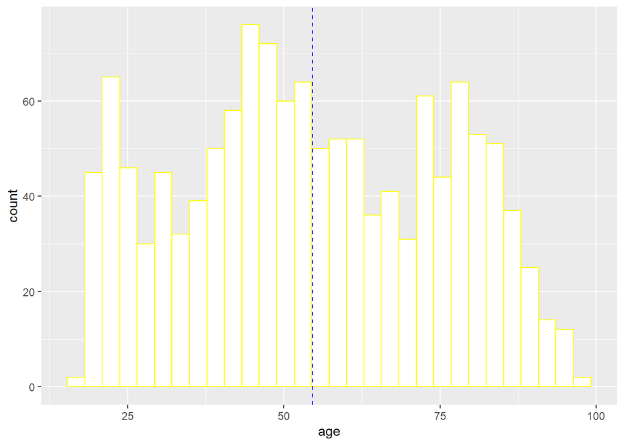

```r
ggplot(data = dataframe, mapping = aes(x = age)) +
  geom_histogram(
     col = "yellow",
     fill = "white")+
  geom_vline(aes(xintercept = mean(age)), color = 'blue',linetype ="dashed")
```

Histogram depicts the distribution of age among the observations and number of counts with ages . The dotted line indicates the mean age of the data set which is 54.5

**Visualizing** Length of stay in ICU with Age using geom_hex

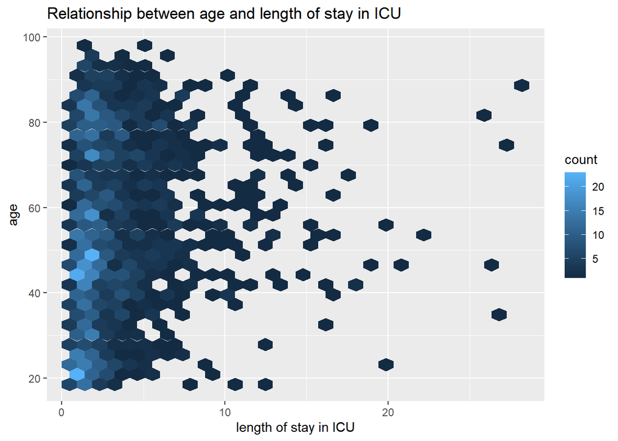

```r
ggplot(data = dataframe, mapping = aes(x = icu_los_day, y = age)) +
  geom_hex()+
  xlab('length of stay in ICU')+
  ylab('age')+
  labs(title = "Relationship between age and length of stay in ICU")
```

This depicts the length of stay in ICU is relatively lower that is 3.4, This makes sense because only critical care is provided and once stabilized the patients will be moved to palliative care or recovery phase.

Checking LOS(Length of Stay) in hospitals of elder age patients with younger age patients

```r
summary(dataframe $ age)
```

```
##    Min. 1st Qu.  Median    Mean 3rd Qu.    Max.
##   18.11   38.92   53.22   54.60   72.76   99.11
```

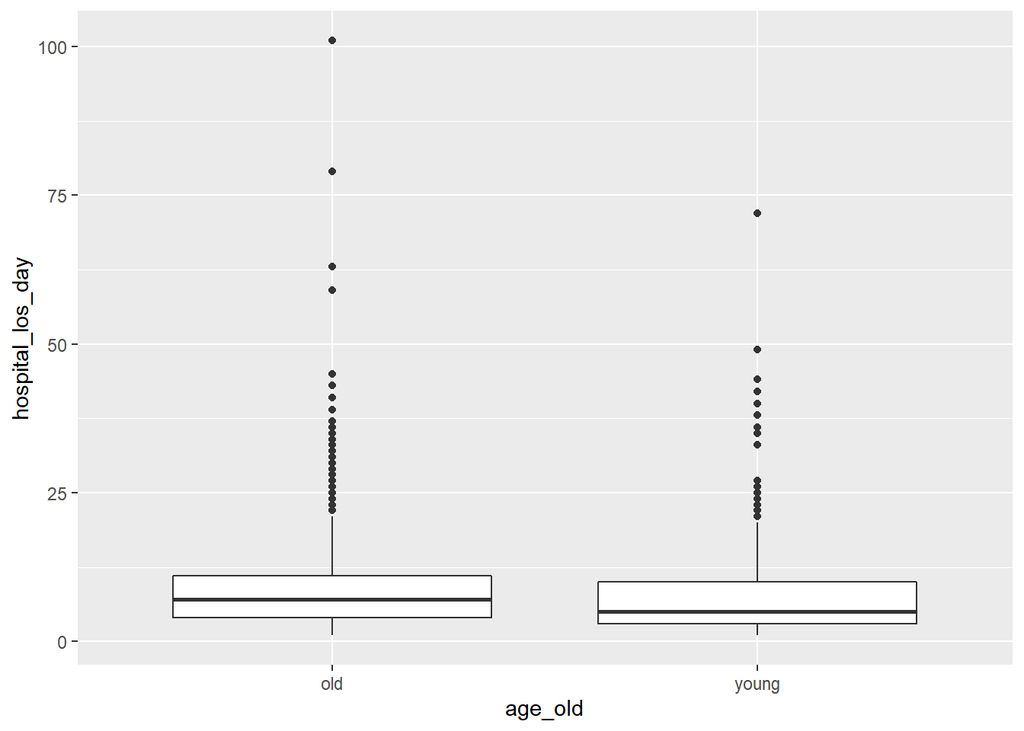

```r
dataframe $ age_old <- ifelse(dataframe $ age > 50, 'old','young')
ggplot(data = dataframe, mapping = aes(y = hospital_los_day, x = age_old)) +
  geom_boxplot()
```

Length of stay in younger patients is lower than older patients Other factors which could affect this could be mortality rates related to old ages.

**Linear regression** using multiple variables

```r
score_model <- lm(hospital_los_day ~ mal_flg+stroke_flg +bmi+age, data = dataframe)
summary(score_model)
```

```
##
## Call:
## lm(formula = hospital_los_day ~ mal_flg + stroke_flg + bmi +
##     age, data = dataframe)
##
## Residuals:
##     Min      1Q  Median      3Q     Max
## -10.151  -4.961  -2.298   2.152  92.331
##
## Coefficients:
##             Estimate Std. Error t value Pr(>|t|)
## (Intercept)  5.55258    1.02461   5.419 7.12e-08 ***
## mal_flg      1.89493    0.66462   2.851  0.00442 **
## stroke_flg  -1.13658    0.75612  -1.503  0.13303
## bmi          0.03525    0.02792   1.263  0.20697
## age          0.03124    0.01159   2.696  0.00711 **
## ---
## Signif. codes:  0 '***' 0.001 '**' 0.01 '*' 0.05 '.' 0.1 ' ' 1
##
## Residual standard error: 8.255 on 1304 degrees of freedom
## Multiple R-squared:  0.01572,    Adjusted R-squared:  0.0127
## F-statistic: 5.207 on 4 and 1304 DF,  p-value: 0.0003664
```

Get **regression table**: #summary(score_model)

```r
get_regression_table(score_model)
```

```
## # A tibble: 5 x 7
##   term       estimate std_error statistic p_value lower_ci upper_ci
##   <chr>         <dbl>     <dbl>     <dbl>   <dbl>    <dbl>    <dbl>
## 1 intercept     5.55      1.02       5.42   0        3.54     7.56
## 2 mal_flg       1.90      0.665      2.85   0.004    0.591    3.20
## 3 stroke_flg   -1.14      0.756     -1.50   0.133   -2.62     0.347
## 4 bmi           0.035     0.028      1.26   0.207   -0.02     0.09
## 5 age           0.031     0.012      2.70   0.007    0.009    0.054
```

Inference : length in hospital is significantly affected by malignancy and age of the patient.

**bootstrap distribution of mean BMI*

```r
bootstrap_mean <- dataframe %>%
  specify(response = bmi) %>%
  generate(reps = 1000, type = "bootstrap") %>%
  calculate('stat'= 'mean')
```

**calculating the 95% confidence interval of this bootstrap distribution using the percentile method**

```r
a <- bootstrap_mean %>% get_confidence_interval(level = 0.95, type = "percentile")
print(a)
```

```
## # A tibble: 1 x 2
##   lower_ci upper_ci
##      <dbl>    <dbl>
## 1     27.4     28.2
```

**Hypothesis Testing:**

*Null hypothesis*: There is NO difference in Death rates in ICU between males and females

*Alternative hypothesis*: There is difference in Death rates in ICU between males and females

```r
nulldist <- dataframe %>%
  specify(formula =  icu_exp_flg ~ gender )%>%
  hypothesize(null = 'independence')%>%
  generate(reps = 1000, type = "permute")%>%
  calculate(stat = "diff in means", order = c('Male','Female'))
```

Now we’ve got null distribution.

Bootstrap + Simulation:

```r
obs_diff_means <- dataframe %>%
    specify(formula = icu_exp_flg ~ gender) %>%
    calculate(stat = "diff in means",order = c('Male','Female'))
```

**p -value :**

```r
significance <- nulldist %>%
  get_p_value(obs_stat = obs_diff_means, direction = "both")
```

```r
significance
```

```
## # A tibble: 1 x 1
##   p_value
##     <dbl>
## 1   0.006
```

p -value is 0.01. As it is less than 0.050 which is usually considered to be significant. We can **reject the NULL hypothesis** and say that there is correlation between gender and deaths in ICU, But we do need to keep factors like sepsis, Congestive heart failure, Atrial fibrillation, Chronic renal disease, Liver Disease, Chronic obstructive pulmonary disease, Coronary artery disease, Stroke, Malignancy, Respiratory disease etc in mind which could affect the death rates not only in ICU’s but also in hospitals.